# gym

### **LOADING LIBRARIES AND DATA:**

```python
import pandas as pd
import numpy as np
import matplotlib.pyplot as plt
import seaborn as sns
from sklearn.model_selection import train_test_split
from sklearn.linear_model import LogisticRegression, LinearRegression
from sklearn.metrics import classification_report, confusion_matrix, accuracy_score, mean_squared_error, r2_score
from sklearn.preprocessing import StandardScaler
```

```python
# Load the data for both problems
gym_data = pd.read_csv('problem1.csv')
class_data = pd.read_csv('problem2.csv')
```

### **PROBLEM A:** Optimizing Group Fitness Class Utilization

#### Exploratory Data Analysis:

```python
class_data.head(5)
```

|  | booking_id | months_as_member | weight | days_before | day_of_week | time | category | attended |
| --- | --- | --- | --- | --- | --- | --- | --- | --- |
| 0 | 1 | 17 | 79.56 | 8 | Wed | PM | Strength | 0 |
| 1 | 2 | 10 | 79.01 | 2 | Mon | AM | HIIT | 0 |
| 2 | 3 | 16 | 74.53 | 14 | Sun | AM | Strength | 0 |
| 3 | 4 | 5 | 86.12 | 10 | Fri | AM | Cycling | 0 |
| 4 | 5 | 15 | 69.29 | 8 | Thu | AM | HIIT | 0 |

```python
class_data.info()
```

```
<class 'pandas.core.frame.DataFrame'>
RangeIndex: 1500 entries, 0 to 1499
Data columns (total 8 columns):
 #   Column            Non-Null Count  Dtype
---  ------            --------------  -----
 0   booking_id        1500 non-null   int64
 1   months_as_member  1500 non-null   int64
 2   weight            1480 non-null   float64
 3   days_before       1500 non-null   object
 4   day_of_week       1500 non-null   object
 5   time              1500 non-null   object
 6   category          1500 non-null   object
 7   attended          1500 non-null   int64
dtypes: float64(1), int64(3), object(4)
memory usage: 93.9+ KB
```

Columns like 'days_before' can be of type integer, but it is of type 'object'. We will check the data in the column to see if requires any form of normalization.

```python
unique_days_before = class_data['days_before'].unique()
print("Unique days before:", unique_days_before)
```

```
Unique days before: ['8' '2' '14' '10' '6' '4' '9' '12' '5' '3' '7' '13' '12 days' '20' '1'
 '15' '6 days' '11' '13 days' '3 days' '16' '1 days' '7 days' '8 days'
 '10 days' '14 days' '17' '5 days' '2 days' '4 days' '29']
```

There are data with 'days' mentioned, which is not required. We can remove the 'days' string and maintain the column as an integer column.

```python
# Remove 'days' from the entries and convert the column to integers
class_data['days_before'] = class_data['days_before'].str.replace(' days', '').astype(int)

unique_days_before = class_data['days_before'].unique()
print("Unique days before:", unique_days_before)
```

```
Unique days before: [ 8  2 14 10  6  4  9 12  5  3  7 13 20  1 15 11 16 17 29]
```

Now that we have checked this, it is also possible that 'day_of_week' column has entries like 'Fri' and 'Friday' in it. We will check for it.

```python
unique_days = class_data['day_of_week'].unique()
print("Unique days of the week:", unique_days)
```

```
Unique days of the week: ['Wed' 'Mon' 'Sun' 'Fri' 'Thu' 'Wednesday' 'Fri.' 'Tue' 'Sat' 'Monday']
```

Just as guessed, the values are not normalized, we will retain just the first 3 letters of the entries so that all entries would be of the same form.

```python
class_data['day_of_week'] = class_data['day_of_week'].str[:3]

unique_days = class_data['day_of_week'].unique()
print("Unique days of the week:", unique_days)
```

```
Unique days of the week: ['Wed' 'Mon' 'Sun' 'Fri' 'Thu' 'Tue' 'Sat']
```

We will check the same for time and category columns just to be sure of this case.

```python
unique_time = class_data['time'].unique()
print("Unique time:", unique_time)

unique_category = class_data['category'].unique()
print("Unique category:", unique_category)
```

```
Unique time: ['PM' 'AM']
Unique category: ['Strength' 'HIIT' 'Cycling' 'Yoga' '-' 'Aqua']
```

Both the columns have proper data entries. No more data normalization is required. We will convert the left out 'day_of_week', 'time' and 'category' columns into numerical form by categorizing the values. The 'time' column can be converted into 'is_AM' and the values can be 1 for 'AM' and 0 for 'PM'.

```python
# Convert time to numerical column with values 0 for AM and 1 for PM
class_data['time'] = class_data['time'].apply(lambda x: 1 if x == 'AM' else 0)
```

```python
from sklearn.preprocessing import LabelEncoder

# Initialize the label encoder
label_encoder = LabelEncoder()

# Encode the 'day_of_week' column
class_data['day_of_week'] = label_encoder.fit_transform(class_data['day_of_week'])

# Encode the 'category' column
class_data['category'] = label_encoder.fit_transform(class_data['category'])
```

We will check for missing data so that we can replace them with mean value of that column.

```python
# Check for missing data
missing_data = class_data.isnull().sum()

print("Missing data in each column:")
print(missing_data)
```

```
Missing data in each column:
booking_id           0
months_as_member     0
weight              20
days_before          0
day_of_week          0
time                 0
category             0
attended             0
dtype: int64
```

'weight' column has missing values, though person's weight can't be synthesized correctly, we could use a metric like 'mean' value to replace them and still retain the other data to train the model.

```python
# Calculate the mean of the 'weight' column, excluding missing values
mean_weight = class_data['weight'].mean()

# Replace missing values in the 'weight' column with the mean value
class_data['weight'].fillna(mean_weight, inplace=True)
```

```python
class_data.describe()
```

|  | booking_id | months_as_member | weight | days_before | day_of_week | time | category | attended |
| --- | --- | --- | --- | --- | --- | --- | --- | --- |
| count | 1500.000000 | 1500.000000 | 1500.000000 | 1500.000000 | 1500.000000 | 1500.000000 | 1500.000000 | 1500.000000 |
| mean | 750.500000 | 15.628667 | 82.610378 | 8.346667 | 2.604000 | 0.760667 | 2.957333 | 0.302667 |
| std | 433.157015 | 12.926543 | 12.680411 | 4.077938 | 1.948088 | 0.426819 | 1.022518 | 0.459565 |
| min | 1.000000 | 1.000000 | 55.410000 | 1.000000 | 0.000000 | 0.000000 | 0.000000 | 0.000000 |
| 25% | 375.750000 | 8.000000 | 73.562500 | 4.000000 | 1.000000 | 1.000000 | 2.000000 | 0.000000 |
| 50% | 750.500000 | 12.000000 | 81.035000 | 9.000000 | 3.000000 | 1.000000 | 3.000000 | 0.000000 |
| 75% | 1125.250000 | 19.000000 | 89.382500 | 12.000000 | 4.000000 | 1.000000 | 3.000000 | 1.000000 |
| max | 1500.000000 | 148.000000 | 170.520000 | 29.000000 | 6.000000 | 1.000000 | 5.000000 | 1.000000 |

Now that we have converted all the columns into numerical form, we can plot distribution and correlation data to do analysis on them.

#### Ratio of people attending class:

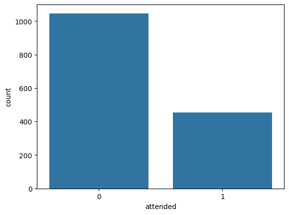

```python
sns.countplot(x='attended', data=class_data)
plt.show()
```

The distribution shows that most of the people did not attend the class according to the data. Almost twice the number of people did not attend the class.

#### Distribution of 'days_before':

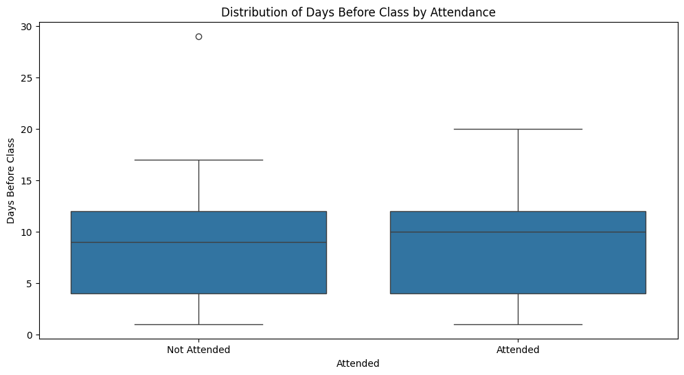

```python
plt.figure(figsize=(12, 6))
sns.boxplot(x='attended', y='days_before', data=class_data)
plt.title('Distribution of Days Before Class by Attendance')
plt.xlabel('Attended')
plt.ylabel('Days Before Class')
plt.xticks([0, 1], ['Not Attended', 'Attended'])
plt.show()
```

The distribution shows that people who have attended and not attended classes looks almost the same. This indicates that the 'days_before' column does not act as a deciding factor. We can check which column affects the target variable by plotting out the correlation matrix.

#### Correlation Matrix:

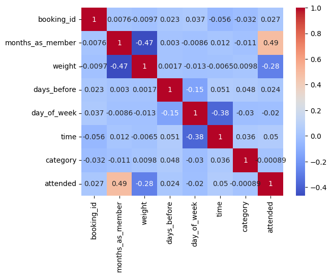

```python
sns.heatmap(class_data.corr(), annot=True, cmap='coolwarm')
plt.show()
```

The correlation matrix shows that 'months_as_member' column has high positive correlation with the target column 'attended'. This explains that the longer the person has stayed as member of the gym, more the probability of them attending the class. The column 'weight' has the highest negative correlation with the column 'attended' i.e., the lesser the weight of the person, more the probability of them attending the class.

From the two results, we could assume that people who stayed disciplined in attending the gym sessions and saw weight loss are the people who preferred to attend the classes. This means that we should work towards making people interested to attend the gym properly. We could share the weight loss journey of people who have seen visible results to motive the newly joined members. We could make them special offers such as discounts in membership cost when there is seasonal drop in membership count.

#### Model Training and Evaluation:

Training ML model to predict if a person will attend the class or not and target that person will offers and loyalty enhancement program.

```python
X_class = class_data.drop('attended', axis=1)
y_class = class_data['attended']
X_train_class, X_test_class, y_train_class, y_test_class = train_test_split(X_class, y_class, test_size=0.2, random_state=42)
```

Since the data has class imbalance i.e., the class 'not_attended' has twice the number of data compared to class 'attended', we will adjust class weights in the model to refrain from overfitting the model.

```python
from sklearn.utils.class_weight import compute_class_weight

# Compute class weights
class_weights = compute_class_weight(
    class_weight='balanced',
    classes=[0, 1],
    y=y_train_class
)
```

```python
# Create a dictionary with class weights
class_weight_dict = {0: class_weights[0], 1: class_weights[1]}
```

Normalizing data using Standard Scaler to feed normalized data into the model:

```python
scaler = StandardScaler()
X_train_class = scaler.fit_transform(X_train_class)
X_test_class = scaler.transform(X_test_class)
```

Model without class weight:

```python
model_class = LogisticRegression()
model_class.fit(X_train_class, y_train_class)

# Predict on training data
y_train_pred_class = model_class.predict(X_train_class)

# Calculate training accuracy
training_accuracy = accuracy_score(y_train_class, y_train_pred_class)

# Print the training accuracy
print(f'Training Accuracy: {training_accuracy:.2f}')

y_pred_class = model_class.predict(X_test_class)

print("Classification Report for Class Attendance Prediction:")
print(classification_report(y_test_class, y_pred_class))
```

```
Training Accuracy: 0.78
Classification Report for Class Attendance Prediction:
              precision    recall  f1-score   support

           0       0.75      0.94      0.84       197
           1       0.78      0.41      0.54       103

    accuracy                           0.76       300
   macro avg       0.76      0.67      0.69       300
weighted avg       0.76      0.76      0.73       300
```

Model with class weight:

```python
model_class = LogisticRegression(class_weight=class_weight_dict)
model_class.fit(X_train_class, y_train_class)

# Predict on training data
y_train_pred_class = model_class.predict(X_train_class)

# Calculate training accuracy
training_accuracy = accuracy_score(y_train_class, y_train_pred_class)

# Print the training accuracy
print(f'Training Accuracy: {training_accuracy:.2f}')

y_pred_class = model_class.predict(X_test_class)

print("Classification Report for Class Attendance Prediction:")
print(classification_report(y_test_class, y_pred_class))
```

```
Training Accuracy: 0.77
Classification Report for Class Attendance Prediction:
              precision    recall  f1-score   support

           0       0.83      0.82      0.83       197
           1       0.67      0.68      0.67       103

    accuracy                           0.77       300
   macro avg       0.75      0.75      0.75       300
weighted avg       0.77      0.77      0.77       300
```

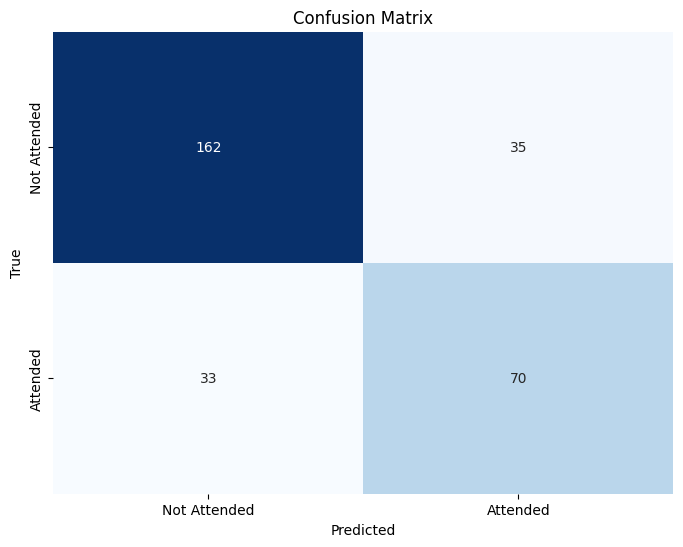

```python
cm = confusion_matrix(y_test_class, y_pred_class)

plt.figure(figsize=(8, 6))
sns.heatmap(cm, annot=True, fmt='d', cmap='Blues', cbar=False,
            xticklabels=['Not Attended', 'Attended'],
            yticklabels=['Not Attended', 'Attended'])
plt.title('Confusion Matrix')
plt.xlabel('Predicted')
plt.ylabel('True')
plt.show()
```

The model accuracy and prediction is around 77%. The lower accuracy rate for the model could be because of class imbalance. There are twice the number of data for class 'not_attended' when compared to 'attended'. After guessing model overfitting and feeding the model with class weights, still the accuracy has not improved much.

```python
from sklearn.ensemble import RandomForestClassifier

# Initialize the Random Forest model
model = RandomForestClassifier()

# Fit the model on training data
model.fit(X_train_class, y_train_class)

# Predict on training data
y_train_pred_class = model_class.predict(X_train_class)

# Calculate training accuracy
training_accuracy = accuracy_score(y_train_class, y_train_pred_class)

# Print the training accuracy
print(f'Training Accuracy: {training_accuracy:.2f}')

y_pred_class = model_class.predict(X_test_class)

print("Classification Report for Class Attendance Prediction:")
print(classification_report(y_test_class, y_pred_class))
```

```
Training Accuracy: 0.77
Classification Report for Class Attendance Prediction:
              precision    recall  f1-score   support

           0       0.83      0.82      0.83       197
           1       0.67      0.68      0.67       103

    accuracy                           0.77       300
   macro avg       0.75      0.75      0.75       300
weighted avg       0.77      0.77      0.77       300
```

```python
from sklearn.naive_bayes import GaussianNB

model = GaussianNB()

# Fit the model on training data
model.fit(X_train_class, y_train_class)

# Predict on training data
y_train_pred_class = model_class.predict(X_train_class)

# Calculate training accuracy
training_accuracy = accuracy_score(y_train_class, y_train_pred_class)

# Print the training accuracy
print(f'Training Accuracy: {training_accuracy:.2f}')

y_pred_class = model_class.predict(X_test_class)

print("Classification Report for Class Attendance Prediction:")
print(classification_report(y_test_class, y_pred_class))
```

```
Training Accuracy: 0.77
Classification Report for Class Attendance Prediction:
              precision    recall  f1-score   support

           0       0.83      0.82      0.83       197
           1       0.67      0.68      0.67       103

    accuracy                           0.77       300
   macro avg       0.75      0.75      0.75       300
weighted avg       0.77      0.77      0.77       300
```

```python
gym_data.head(5)
```

|  | number_people | date | timestamp | day_of_week | is_weekend | is_holiday | temperature | is_start_of_semester | is_during_semester | month | hour |
| --- | --- | --- | --- | --- | --- | --- | --- | --- | --- | --- | --- |
| 0 | 37 | 2015-08-14 17:00:11-07:00 | 61211 | 4 | 0 | 0 | 71.76 | 0 | 0 | 8 | 17 |
| 1 | 45 | 2015-08-14 17:20:14-07:00 | 62414 | 4 | 0 | 0 | 71.76 | 0 | 0 | 8 | 17 |
| 2 | 40 | 2015-08-14 17:30:15-07:00 | 63015 | 4 | 0 | 0 | 71.76 | 0 | 0 | 8 | 17 |
| 3 | 44 | 2015-08-14 17:40:16-07:00 | 63616 | 4 | 0 | 0 | 71.76 | 0 | 0 | 8 | 17 |
| 4 | 45 | 2015-08-14 17:50:17-07:00 | 64217 | 4 | 0 | 0 | 71.76 | 0 | 0 | 8 | 17 |

```python
gym_data.info()
```

```
<class 'pandas.core.frame.DataFrame'>
RangeIndex: 62184 entries, 0 to 62183
Data columns (total 11 columns):
 #   Column                Non-Null Count  Dtype
---  ------                --------------  -----
 0   number_people         62184 non-null  int64
 1   date                  62184 non-null  object
 2   timestamp             62184 non-null  int64
 3   day_of_week           62184 non-null  int64
 4   is_weekend            62184 non-null  int64
 5   is_holiday            62184 non-null  int64
 6   temperature           62184 non-null  float64
 7   is_start_of_semester  62184 non-null  int64
 8   is_during_semester    62184 non-null  int64
 9   month                 62184 non-null  int64
 10  hour                  62184 non-null  int64
dtypes: float64(1), int64(9), object(1)
memory usage: 5.2+ MB
```

The only column that has to be converted into numerical form here is 'date'. 'month' and 'hour' are already there as separate columns in the data. We need to extract just the 'day' and 'year' details from the 'date' column. We will extract the information and remove the 'date' column from the data.

```python
# Convert 'date' column to datetime, including timezone info
gym_data['date'] = pd.to_datetime(gym_data['date'], format='%Y-%m-%d %H:%M:%S%z', errors='coerce')

# Convert 'date' column to datetime64[ns] type
gym_data['date'] = pd.to_datetime(gym_data['date'], errors='coerce', utc=True)

# Extract 'day' and 'year' from 'date' column
gym_data['day'] = gym_data['date'].dt.day
gym_data['year'] = gym_data['date'].dt.year.astype(int)

# Drop the 'date' column
gym_data = gym_data.drop(columns=['date'])
```

The 'timestamp' column is not necessary now since we have 'hour' information. The remaining seconds information is that of a deciding factor for prediction. We can remove it as well.

```python
gym_data = gym_data.drop(columns=['timestamp'])
```

Based on the month information, we can identify which season of the year it is and based on it, we can guess if more people attend the gym during a season.

```python
gym_data['season'] = gym_data['month'].apply(lambda x: 'Winter' if x in [12, 1, 2]
                                                    else 'Spring' if x in [3, 4, 5]
                                                    else 'Summer' if x in [6, 7, 8]
                                                    else 'Fall')
```

```python
gym_data['season'] = label_encoder.fit_transform(gym_data['season'])

# Get the class labels and their corresponding encoded values
classes = label_encoder.classes_
labels = label_encoder.transform(classes)

# Print the classes and their corresponding labels
for class_name, label in zip(classes, labels):
    print(f'Class: {class_name}, Label: {label}')
```

```
Class: Fall, Label: 0
Class: Spring, Label: 1
Class: Summer, Label: 2
Class: Winter, Label: 3
```

Now that we have converted all the columns into numerical form, we will find the correlation between all the columns with the target column 'number_of_people'.

```python
gym_data.head(10)
```

|  | number_people | day_of_week | is_weekend | is_holiday | temperature | is_start_of_semester | is_during_semester | month | hour | day | year | season |
| --- | --- | --- | --- | --- | --- | --- | --- | --- | --- | --- | --- | --- |
| 0 | 37 | 4 | 0 | 0 | 71.76 | 0 | 0 | 8 | 17 | 15 | 2015 | 2 |
| 1 | 45 | 4 | 0 | 0 | 71.76 | 0 | 0 | 8 | 17 | 15 | 2015 | 2 |
| 2 | 40 | 4 | 0 | 0 | 71.76 | 0 | 0 | 8 | 17 | 15 | 2015 | 2 |
| 3 | 44 | 4 | 0 | 0 | 71.76 | 0 | 0 | 8 | 17 | 15 | 2015 | 2 |
| 4 | 45 | 4 | 0 | 0 | 71.76 | 0 | 0 | 8 | 17 | 15 | 2015 | 2 |
| 5 | 46 | 4 | 0 | 0 | 72.15 | 0 | 0 | 8 | 18 | 15 | 2015 | 2 |
| 6 | 43 | 4 | 0 | 0 | 72.15 | 0 | 0 | 8 | 18 | 15 | 2015 | 2 |
| 7 | 53 | 4 | 0 | 0 | 72.15 | 0 | 0 | 8 | 18 | 15 | 2015 | 2 |
| 8 | 54 | 4 | 0 | 0 | 72.15 | 0 | 0 | 8 | 18 | 15 | 2015 | 2 |
| 9 | 43 | 4 | 0 | 0 | 72.15 | 0 | 0 | 8 | 18 | 15 | 2015 | 2 |

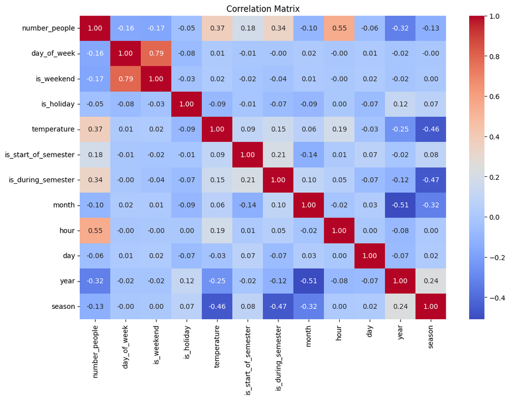

```python
corr_matrix = gym_data.corr()

plt.figure(figsize=(12, 8))
sns.heatmap(corr_matrix, annot=True, cmap='coolwarm', fmt='.2f')
plt.title('Correlation Matrix')
plt.show()
```

The column with highest positive correlation is 'hour'. The column with most negative correlation is 'year'. From the data we could say that number of people attending gym increases as the hour of the day increases and has reduced as the year went by. People use the most resources in the later hours of the day. Whatever change the gym went through in the recent years could be the cause for people not attending the gym. With this information, gym institution can make changes to their schedule or manage conducting sessions accordingly.

'temperature' and 'is_during_semester' also are also reasonable deciding factors of the target variable. It means if the temperature is high or during the semester, people tend to attend gym more.

#### Distribution of number of people:

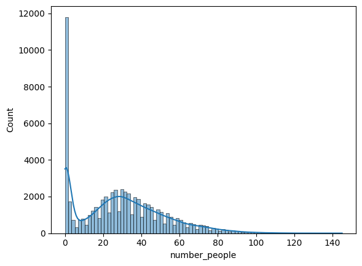

```python
sns.histplot(gym_data['number_people'], kde=True)
plt.show()
```

```python
# Calculate the median value of the 'number_people' column
median_count = gym_data['number_people'].median()
print(f"Median Number of People: {median_count}")
```

```
Median Number of People: 28.0
```

```python
# Create a new column 'above_median' where 1 indicates 'number_people' > median, and 0 otherwise
gym_data['above_median'] = (gym_data['number_people'] > median_count).astype(int)
```

```python
# Drop the old 'number_people' column if it's no longer needed
gym_data = gym_data.drop(columns=['number_people'])
```

#### Model Training and Evaluation:

```python
X_gym = gym_data.drop('above_median', axis=1)
y_gym = gym_data['above_median']
X_train_gym, X_test_gym, y_train_gym, y_test_gym = train_test_split(X_gym, y_gym, test_size=0.2, random_state=42)
```

```python
X_train_gym = scaler.fit_transform(X_train_gym)
X_test_gym = scaler.transform(X_test_gym)
```

```python
model_gym = LogisticRegression()
model_gym.fit(X_train_gym, y_train_gym)

# Predict on training data
y_train_pred_gym = model_gym.predict(X_train_gym)

# Calculate training accuracy
training_accuracy = accuracy_score(y_train_gym, y_train_pred_gym)

# Print the training accuracy
print(f'Training Accuracy: {training_accuracy:.2f}')

y_pred_gym = model_gym.predict(X_test_gym)

print("Classification Report for Class Attendance Prediction:")
print(classification_report(y_test_gym, y_pred_gym))
```

```
Training Accuracy: 0.81
Classification Report for Class Attendance Prediction:
              precision    recall  f1-score   support

           0       0.83      0.81      0.82      6371
           1       0.80      0.82      0.81      6066

    accuracy                           0.81     12437
   macro avg       0.81      0.81      0.81     12437
weighted avg       0.81      0.81      0.81     12437
```

```python
model_gym = GaussianNB()
model_gym.fit(X_train_gym, y_train_gym)

# Predict on training data
y_train_pred_gym = model_gym.predict(X_train_gym)

# Calculate training accuracy
training_accuracy = accuracy_score(y_train_gym, y_train_pred_gym)

# Print the training accuracy
print(f'Training Accuracy: {training_accuracy:.2f}')

y_pred_gym = model_gym.predict(X_test_gym)

print("Classification Report for Class Attendance Prediction:")
print(classification_report(y_test_gym, y_pred_gym))
```

```
Training Accuracy: 0.77
Classification Report for Class Attendance Prediction:
              precision    recall  f1-score   support

           0       0.89      0.62      0.73      6371
           1       0.70      0.92      0.79      6066

    accuracy                           0.77     12437
   macro avg       0.80      0.77      0.76     12437
weighted avg       0.80      0.77      0.76     12437
```

```python
# Initialize the Random Forest model
model_gym = RandomForestClassifier()

model_gym.fit(X_train_gym, y_train_gym)

# Predict on training data
y_train_pred_gym = model_gym.predict(X_train_gym)

# Calculate training accuracy
training_accuracy = accuracy_score(y_train_gym, y_train_pred_gym)

# Print the training accuracy
print(f'Training Accuracy: {training_accuracy:.2f}')

y_pred_gym = model_gym.predict(X_test_gym)

print("Classification Report for Class Attendance Prediction:")
print(classification_report(y_test_gym, y_pred_gym))
```

```
Training Accuracy: 0.94
Classification Report for Class Attendance Prediction:
              precision    recall  f1-score   support

           0       0.92      0.91      0.91      6371
           1       0.90      0.92      0.91      6066

    accuracy                           0.91     12437
   macro avg       0.91      0.91      0.91     12437
weighted avg       0.91      0.91      0.91     12437
```

While comparing the 3 models, RandomForestClassifier has the highest accuracy and precision. The models works best in finding out if the number of people will be higher than the median value or not.

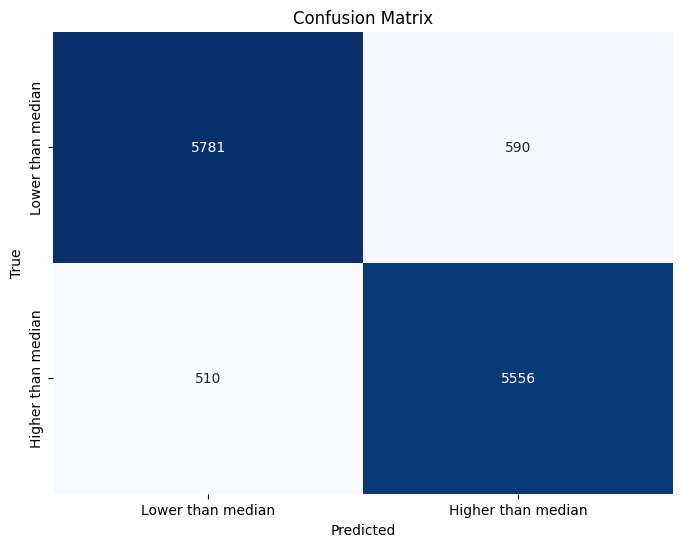

```python
cm = confusion_matrix(y_test_gym, y_pred_gym)

plt.figure(figsize=(8, 6))
sns.heatmap(cm, annot=True, fmt='d', cmap='Blues', cbar=False,
            xticklabels=['Lower than median', 'Higher than median'],
            yticklabels=['Lower than median', 'Higher than median'])
plt.title('Confusion Matrix')
plt.xlabel('Predicted')
plt.ylabel('True')
plt.show()
```

The model even has high precision which is 92% for class 'Lower than median' and 90% for 'Higher than median'. Hence this model is efficient in predicting how crowded the gym will be.